# Laboratorio 3: Hiperplano de máxima separación - Caso no lineal separable

Optimización Convexa en Aprendizaje Automático

Autor/a

Víctor Aceña Gil - Antonio Alonso Ayuso

Fecha de publicación

4 de agosto de 2026

# 1 Generar un conjunto de datos

Supongamos ahora que tenemos dos clases con separables, pero no linealmente separables. ¿Cómo podemos construir un hiperplano que separe esas dos clases?

En este ejemplo, generamos un conjunto de datos que no es separable linealmente en su espacio original, utilizando una distribución de puntos alrededor de una circunferencia. Este tipo de conjunto de datos es ideal para demostrar cómo se pueden separar las clases que no son linealmente separables en su forma original mediante el uso de transformaciones adecuadas.

## 1.1 Creación del conjunto de datos

Este enfoque nos ayuda a entender mejor cómo ciertas transformaciones pueden hacer que un conjunto de datos no linealmente separable se convierta en separable en un espacio de mayor dimensión.

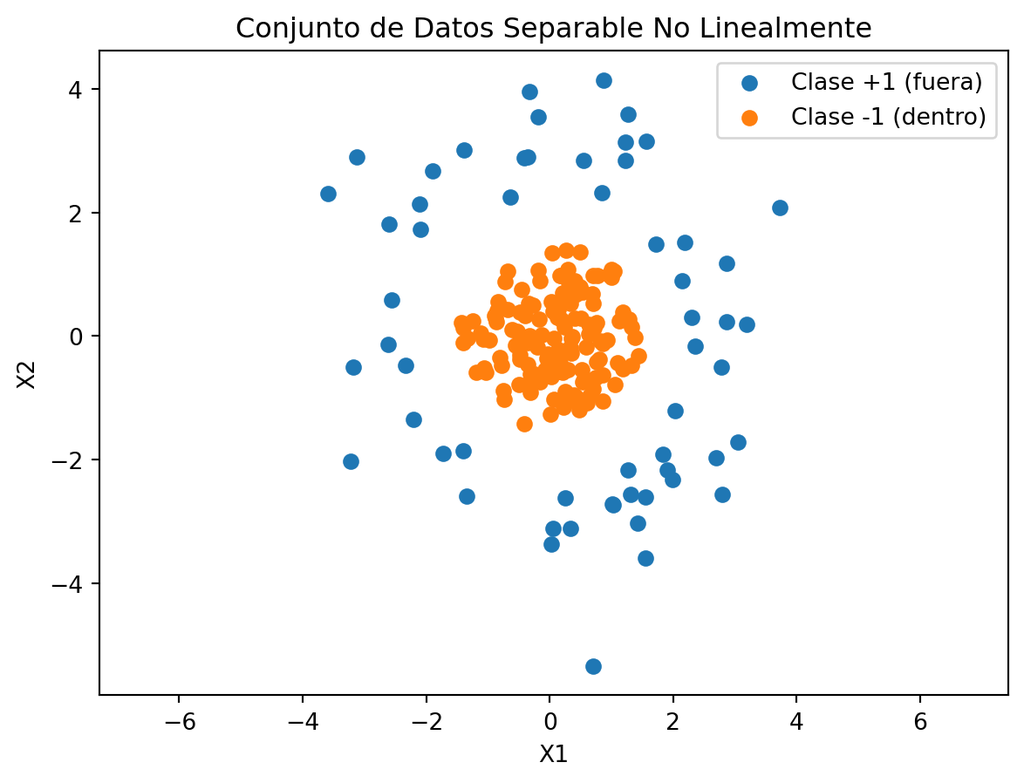

```python
import numpy as np
import matplotlib.pyplot as plt

# Configurar la semilla para reproducibilidad
np.random.seed(1234)

# Generar datos aleatorios
X = np.random.randn(200, 2)

# Definir el radio de la circunferencia
radius = 1.5

# Asignar etiquetas basadas en la posición relativa a la circunferencia
Y = np.array([1 if (x[0]**2 + x[1]**2) >= radius**2 else -1 for x in X])

# Ajustar los puntos para una mayor separación
X[Y == 1] *= 1.5  # Alejar los puntos de la clase +1 del centro
X[Y == -1] /= 1  # Acercar los puntos de la clase -1 hacia el centro

# Visualizar los datos
plt.scatter(X[Y == 1][:, 0], X[Y == 1][:, 1], label='Clase +1 (fuera)')
plt.scatter(X[Y == -1][:, 0], X[Y == -1][:, 1], label='Clase -1 (dentro)')
plt.xlabel('X1')
plt.ylabel('X2')
plt.legend()
plt.title('Conjunto de Datos Separable No Linealmente')
plt.axis('equal')  # Asegurar que los ejes tengan la misma escala
plt.show()
```

# 2 Transformar los datos

Sin embargo, ¿qué sucedería si aumentamos la dimensión? Podemos convertir cada vector bidimensional en uno tridimensional. Por ejemplo, podemos crear un mapeo polinomial con la función $\phi: \mathbb{R}^2 \to \mathbb{R}^3$ definida por:

$$\phi(x_1, x_2) = (x_1^2, x_2^2, \sqrt{2} x_1 x_2)$$

Este mapeo eleva al cuadrado cada una de las dos dimensiones originales y añade un tercer término que es el producto de las dos dimensiones originales, escalado por $\sqrt{2}$. Esta transformación nos permite visualizar y trabajar con los datos en un espacio de mayor dimensión, donde podrían ser más fácilmente separables linealmente.

## 2.1 Definir una función de mapeo $\phi$ para transformar los datos

La función $\phi$ es esencial para transformar los datos del espacio original a un espacio de mayor dimensión. Esta transformación es un paso clave para clasificar datos que no son linealmente separables en su espacio original. La elección de $\phi$ depende de las características específicas del conjunto de datos y de la naturaleza del problema de clasificación.

```python
def phi(X):
    """Función de mapeo a tres dimensiones."""
    return np.array([X[:, 0]**2, X[:, 1]**2, np.sqrt(2)*X[:, 0]*X[:, 1]]).T

X_transformed = phi(X)
```

# 3 Visualización de datos en el espacio transformado

Una vez transformados los datos utilizando la función $\phi$, es útil visualizar cómo se distribuyen en el nuevo espacio de características. Esto nos puede dar una idea intuitiva de cómo la transformación ha afectado la separabilidad de las clases.

Utilizamos `plotly` para crear una visualización 3D interactiva de los datos transformados. En esta visualización, representamos los puntos de la clase +1 y la clase -1 en diferentes colores para observar cómo se distribuyen en el espacio tridimensional generado por $\phi$.

Esta visualización nos ayuda a entender mejor la estructura del espacio de características transformado y cómo se puede encontrar un hiperplano que separe eficazmente las clases en este espacio.

## 3.1 Requisitos para la visualización

Para que esta visualización funcione correctamente, se deben cumplir los siguientes requisitos:

1. **Instalación de Plotly**: Asegúrate de tener instalado `plotly` en tu entorno. Puedes instalarlo utilizando `pip install plotly`.
2. **Entorno de Jupyter**: Esta visualización está diseñada para funcionar en un entorno Jupyter Notebook o JupyterLab.
3. **Compatibilidad del Navegador**: Como `plotly` genera visualizaciones interactivas basadas en JavaScript, asegúrate de utilizar un navegador web compatible y que JavaScript esté habilitado.
4. **Conexión a Internet**: Si estás utilizando versiones de `plotly` que requieren conexión a Internet para cargar los scripts de JavaScript, asegúrate de estar conectado.

Estos requisitos garantizarán que puedas visualizar y interactuar con los datos transformados de manera efectiva, lo que te ayudará a entender mejor la estructura del espacio de características transformado y cómo se puede encontrar un hiperplano que separe eficazmente las clases en este espacio.

```python
import plotly.io as pio
pio.renderers.default = 'notebook_connected'
import plotly.graph_objects as go

# Definir el ancho y alto deseados para la figura
ancho_figura = 800  # Ancho en píxeles
alto_figura = 600   # Alto en píxeles

# Datos para el gráfico
pos_points = X_transformed[Y == 1]
neg_points = X_transformed[Y == -1]

# Crear trazas para los puntos
trace1 = go.Scatter3d(x=pos_points[:, 0], y=pos_points[:, 1], z=pos_points[:, 2],
                      mode='markers', marker=dict(size=5), name='Clase +1')
trace2 = go.Scatter3d(x=neg_points[:, 0], y=neg_points[:, 1], z=neg_points[:, 2],
                      mode='markers', marker=dict(size=5), name='Clase -1')

# Crear y mostrar la figura
fig = go.Figure(data=[trace1, trace2])

fig.update_layout(autosize=True,
    scene=dict(
        xaxis=dict(range=[-10, 10]),
        yaxis=dict(range=[-10, 10]),
        zaxis=dict(range=[-10, 10]),
        aspectmode='cube'
    ),
      # Establecer el ancho de la figura
    height=550,  # Establecer el alto de la figura
)
fig.show()
```

[interactive chart not shown]

Podemos comprobar que este tipo de transformación puede ser útil para hacer que datos que no son linealmente separables en su espacio original (como los puntos dentro y fuera de una circunferencia) sean linealmente separables en un espacio de mayor dimensión.

# 4 Formulación del problema primal con $\phi$

Para abordar casos no lineales, transformamos los datos originales utilizando la función $\phi$. En nuestro caso, la función $\phi$ transforma cada vector bidimensional $(x_1, x_2)$ en un vector tridimensional $(x_1^2, x_2^2, \sqrt{2} x_1 x_2)$. Este mapeo nos permite calcular el hiperplano en un espacio de características de mayor dimensión, donde los datos que no son linealmente separables en su espacio original pueden serlo.

La formulación del problema primal en este espacio transformado es:

$$\begin{aligned}
& \underset{\mathbf{w}}{\text{minimizar}}
& & \frac{1}{2} ||w||^2_2\\
& \text{sujeto a}
& & y_i(\mathbf{w}^T\phi(\mathbf{x}_i) + b) \geq 1 \\
& & & i = 1, \ldots, n
\end{aligned}$$

## 4.1 Importancia de la transformación $\phi$

La transformación $\phi$ nos permite tratar con datos no lineales al mapearlos a un espacio de mayor dimensión donde pueden ser linealmente separables. Esto amplía significativamente la aplicabilidad más allá de los conjuntos de datos linealmente separables.

## 4.2 Análisis de convexidad en el espacio transformado

A pesar de la transformación, el problema sigue siendo convexo. La función objetivo $\frac{1}{2} ||w||^2_2$ es una norma cuadrada, por lo tanto, convexa. Las restricciones, aunque ahora involucran la transformación $\phi$, siguen siendo lineales en términos de $w$ y $b$, y por lo tanto también son convexas. Así, la formulación en el espacio transformado mantiene las propiedades de convexidad del problema original. Esto es significativo porque garantiza que cualquier solución local al problema de optimización también será una solución global. Además, las técnicas estándar de optimización convexa pueden utilizarse para encontrar la solución, lo que hace que el problema sea computacionalmente tratable a pesar del aumento en la dimensionalidad causado por la transformación $\phi$.

# 5 Ejemplo de resolución

## 5.1 Definir variables de optimización

Definimos las variables de optimización `w` (pesos) y `b` (sesgo). Estas variables se ajustarán para encontrar el hiperplano de máxima separación en el espacio transformado.

- `w`: Vector de pesos, que define la orientación del hiperplano.
- `b`: Término de sesgo, que define la distancia del hiperplano al origen.

```python
# Formular el problema primal en el espacio transformado
import cvxpy as cp

n, d = X_transformed.shape
w = cp.Variable(d)
b = cp.Variable()
```

## 5.2 Establecer el objetivo de optimización

El objetivo de la optimización es encontrar un hiperplano que maximice la separación entre las dos clases. Esto se logra minimizando una función objetivo que consta de un término principal:

1. **Norma del Vector de Pesos `w`**: La minimización de la norma (longitud) del vector de pesos `w` favorece un hiperplano con un margen grande. Un margen más amplio generalmente implica una mejor generalización en la clasificación.

Matemáticamente, el objetivo se representa como:

$$\underset{\mathbf{w}}{\text{minimizar}} \quad \frac{1}{2} ||\mathbf{w}||_2^2$$

**Nota**: La norma 2 de un vector `w`, denotada como $||\mathbf{w}||_2$, se refiere a la norma euclidiana, que es la longitud del vector en el espacio euclidiano. Esta norma se calcula como la raíz cuadrada de la suma de los cuadrados de sus componentes, es decir, $||\mathbf{w}||_2 = \sqrt{w_1^2 + w_2^2 + \ldots + w_n^2}$. La minimización de esta norma cuadrática contribuye a maximizar el margen entre las clases en el espacio transformado.

```python
import cvxpy as cp
objective = cp.Minimize(0.5 * cp.norm(w, 2))
```

## 5.3 Definir las restricciones

Las restricciones garantizan que todas las muestras de cada clase estén en el lado correcto del hiperplano. Para cada punto de datos $\mathbf{x}_i$ con etiqueta $y_i$, la restricción se define como:

$$y_i(\mathbf{w}^T\phi(\mathbf{x}_i) + b) \geq 1, \quad \text{para todo } i$$

Esto asegura que el producto escalar entre `w` y cada muestra `x` (a través de la función $\phi$), ajustado por `b`, sea suficiente para la clasificación correcta.

```python
import cvxpy as cp
constraints = [cp.multiply(Y, X_transformed @ w + b) >= 1]
```

# 6 Resolver el problema de optimización

Creamos y resolvemos el problema de optimización utilizando las variables, el objetivo y las restricciones definidas. Esto nos permitirá encontrar los valores óptimos de `w` y `b`.

Al resolver este problema, CVXPY automáticamente encuentra la solución que minimiza nuestro objetivo y satisface las restricciones.

```python
import cvxpy as cp
prob = cp.Problem(objective, constraints)

# Resolver el problema primal
prob.solve()
print(f"Valor óptimo de w: {w.value}")
print(f"Valor óptimo de b: {b.value}")
```

```
Valor óptimo de w: [0.64005198 0.64761839 0.03482811]
Valor óptimo de b: -2.4648605482921724
```

## 6.1 Visualizar el hiperplano resultante

Una vez que hemos encontrado el hiperplano óptimo en el espacio transformado, es útil visualizar cómo este hiperplano clasifica los datos en el espacio original. Aunque el hiperplano se encuentra en un espacio de mayor dimensión, podemos proyectar su efecto en el espacio bidimensional original para entender mejor cómo separa las clases.

### 6.1.1 Proyección a dos dimensiones

La ecuación del hiperplano en el espacio transformado se adapta para su visualización en un gráfico bidimensional de la siguiente manera:

Supongamos que la ecuación del hiperplano en el espacio tridimensional transformado es:

$$\mathbf{w}^T \phi(\mathbf{x}) + b = 0$$

donde $\phi(\mathbf{x}) = (x_1^2, x_2^2, \sqrt{2} x_1 x_2)$ y $\mathbf{w} = [w_0, w_1, w_2]$.

Reorganizando la ecuación del hiperplano:

$$w_0 x_1^2 + w_1 x_2^2 + w_2 \sqrt{2} x_1 x_2 + b = 0$$

Para proyectar este hiperplano en un espacio bidimensional, despejamos $x_2$ en función de $x_1$:

$$x_2 = \frac{-w_2 \sqrt{2} x_1 \pm \sqrt{(w_2^2 \cdot 2 - 4w_0w_1) x_1^2 - 4w_1b}}{2w_1}$$

### 6.1.2 Integración de la solución teórica en Python

1. **Predecir Etiquetas en el Espacio Transformado**: Utilizamos una función `predict` que aplica la predicción definida por el hiperplano (incluyendo `w` y `b`) a los datos transformados para predecir las etiquetas.
2. **Crear una Malla de Puntos en el Espacio Original**: Generamos una malla de puntos que cubre el rango de los datos originales.
3. **Transformar la Malla de Puntos**: Aplicamos la transformación $\phi$ a cada punto de la malla para llevarlos al espacio transformado.
4. **Calcular las Predicciones para la Malla de Puntos**: Obtenemos las predicciones del modelo para esta malla transformada.
5. **Visualizar el Límite de Decisión**: Dibujamos el límite de decisión en el espacio original utilizando las predicciones obtenidas. Esto nos muestra cómo el hiperplano en el espacio de mayor dimensión separa las clases en nuestro espacio original bidimensional.

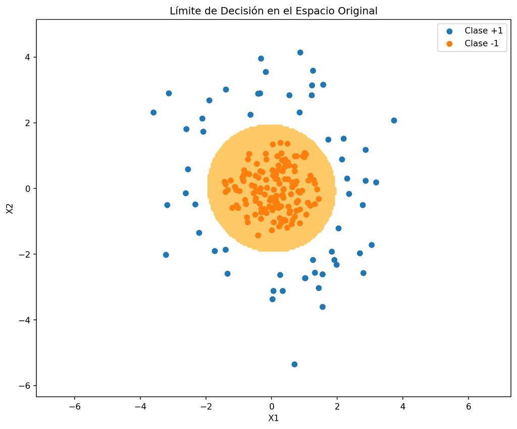

```python
# Función para predecir etiquetas en el espacio transformado
def predict(X):
    return np.sign(X @ w.value + b.value)

# Crear una malla de puntos en el espacio original
x1_min, x1_max = X[:, 0].min() - 1, X[:, 0].max() + 1
x2_min, x2_max = X[:, 1].min() - 1, X[:, 1].max() + 1
xx1, xx2 = np.meshgrid(np.linspace(x1_min, x1_max, 200), np.linspace(x2_min, x2_max, 200))

# Aplicar la transformación φ a la malla de puntos
X_grid = np.c_[xx1.ravel(), xx2.ravel()]
X_grid_transformed = phi(X_grid)

# Calcular las predicciones para la malla de puntos
Z = predict(X_grid_transformed)
Z = Z.reshape(xx1.shape)

# Configurar el tamaño de la figura
plt.figure(figsize=(10, 8))

# Visualizar el límite de decisión en el espacio original
# Solo colorear el interior (donde Z == 1)
plt.contourf(xx1, xx2, Z, levels=[-1, 0, 1], colors=['orange', 'white'], alpha=0.6)
plt.scatter(X[Y == 1][:, 0], X[Y == 1][:, 1], label='Clase +1')
plt.scatter(X[Y == -1][:, 0], X[Y == -1][:, 1], label='Clase -1')
plt.xlabel('X1')
plt.ylabel('X2')
plt.legend()
plt.title('Límite de Decisión en el Espacio Original')
plt.axis('equal')
plt.show()
```

## 6.2 Visualizar el hiperplano resultante en el espacio transformado

Después de transformar los datos y encontrar el hiperplano óptimo en el espacio transformado, podemos visualizar tanto los puntos de datos como el hiperplano en un espacio tridimensional. Esta visualización es útil para entender cómo el hiperplano separa las clases en el espacio transformado.

### 6.2.1 Desarrollo teórico para la representación del hiperplano

La función de mapeo $\phi$ transforma los datos originales a un espacio de mayor dimensión, donde el hiperplano se define por la ecuación:

$$w_0 \cdot x_1^2 + w_1 \cdot x_2^2 + w_2 \cdot \sqrt{2} x_1 x_2 + b = 0$$

En esta ecuación:

- $w_0$, $w_1$, y $w_2$ son los coeficientes del vector de pesos $\mathbf{w}$.
- $x_1$ y $x_2$ son las coordenadas en el espacio original.
- $b$ es el término de sesgo.

Para visualizar este hiperplano en 3D, reorganizamos la ecuación para despejar el término $\sqrt{2} x_1 x_2$, que corresponde a la coordenada z en nuestra visualización:

$$\sqrt{2} x_1 x_2 = -\frac{w_0 \cdot x_1^2 + w_1 \cdot x_2^2 + b}{w_2}$$

### 6.2.2 Creación de la visualización en 3D

1. **Puntos de Datos en el Espacio Transformado**: Creamos dos conjuntos de puntos (trazas), uno para cada clase, usando los datos transformados. Estos puntos se representan en un espacio tridimensional para reflejar su nueva ubicación después de la transformación.
2. **Representación del Hiperplano**: Calculamos los valores de la tercera dimensión (z) del hiperplano basándonos en los valores óptimos de $w$ y $b$ obtenidos. El hiperplano se representa como una superficie en el espacio 3D, lo que nos permite visualizar cómo separa efectivamente las dos clases.
3. **Combinar Puntos y Hiperplano en una Figura**: Utilizamos Plotly para combinar las trazas de los puntos y la superficie del hiperplano en una única figura, lo que nos permite observar la relación entre los puntos de datos y el hiperplano.

### 6.2.3 Visualización con plotly

Utilizamos Plotly, una biblioteca de gráficos interactivos, para crear una visualización 3D que muestre tanto los puntos de datos como el hiperplano. Esta herramienta nos permite explorar la disposición espacial de los puntos y ver cómo el hiperplano determina la clasificación en el espacio transformado.

```python
# Definir el ancho y alto deseados para la figura
ancho_figura = 800  # Ancho en píxeles
alto_figura = 600   # Alto en píxeles

# Asumiendo que X_transformed, Y, w.value, y b.value ya están definidos
# Aquí separas los puntos en positivos y negativos
pos_points = X_transformed[Y == 1]
neg_points = X_transformed[Y == -1]

# Crear trazas para los puntos
trace1 = go.Scatter3d(
    x=pos_points[:, 0], y=pos_points[:, 1], z=pos_points[:, 2],
    mode='markers', marker=dict(size=5), name='Clase +1'
)
trace2 = go.Scatter3d(
    x=neg_points[:, 0], y=neg_points[:, 1], z=neg_points[:, 2],
    mode='markers', marker=dict(size=5), name='Clase -1'
)

# Datos para el hiperplano
xx, yy = np.meshgrid(
    np.linspace(-20, 20, 50),
    np.linspace(-20, 20, 50)
)
zz = -(w.value[0] * xx + w.value[1] * yy + b.value) / w.value[2]

# Crear traza para el hiperplano
hiperplano = go.Surface(x=xx, y=yy, z=zz, colorscale='Viridis', opacity=0.5, showscale=False)

# Crear y configurar la figura
fig = go.Figure(data=[trace1, trace2, hiperplano])

fig.update_layout(
    scene=dict(
        xaxis=dict(range=[-10, 10]),
        yaxis=dict(range=[-10, 10]),
        zaxis=dict(range=[-10, 10]),
        aspectmode='cube'
    ),
    width=ancho_figura,  # Establecer el ancho de la figura
    height=alto_figura,  # Establecer el alto de la figura
)

# Mostrar la figura
fig.show()
```

[interactive chart not shown]